# Bozzi_et_al_R_analysis

All the data to reproduce analysis can be found here: (https://github.com/DavideBozzi/Bozzi_et_al_2020_analysis)

Initial inspection of the reads to identify and remove contaminants. Plotting of the negative controls composition.

Negative controls barplot:

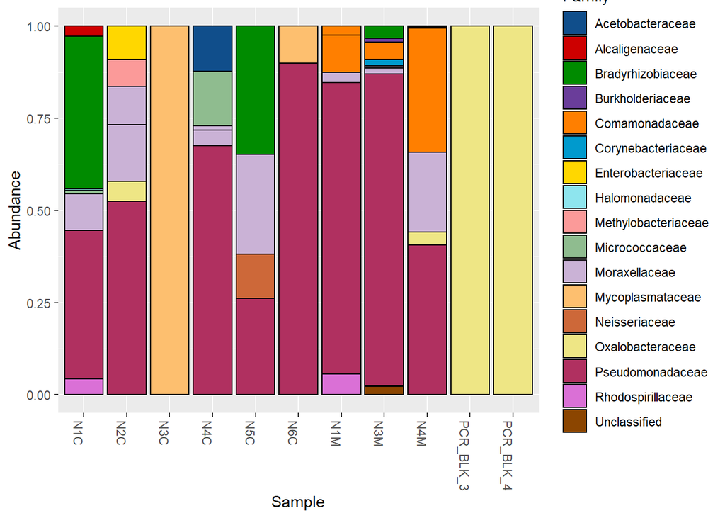

```r
library(phyloseq)
library(ggplot2)

neg_otutable <- read.csv("Negative_controls_otutable.csv", row.names = 1)
taxonomy <- read.csv("OTUs_Taxonomy.csv", header = TRUE, row.names = 1)
taxonomy <- as.matrix(taxonomy)

#create a phyloseq object
neg_otu = otu_table(neg_otutable, taxa_are_rows = TRUE)
tax = tax_table(taxonomy)
neg_physeq1 <- phyloseq(neg_otu, tax)
neg_physeq2 = transform_sample_counts(neg_physeq1, function(x) x / sum(x) )
#order the barplots as you prefer and change palette
neg_layout <- c("N1C", "N2C", "N3C", "N4C", "N5C", "N6C", "N1M", "N3M", "N4M", "PCR_BLK_3",  "PCR_BLK_4")
neg_palette <- c("dodgerblue4", "red3",
                 "green4", "#6A3D9A" , # purple
                 "#FF7F00", # orange
                 "deepskyblue3", "gold1",
                 "cadetblue2", "#FB9A99", # smooth pink
                 "darkseagreen", "#CAB2D6", # smooth purple
                 "#FDBF6F", # smooth orange
                 "sienna3", "khaki2", "maroon",
                 "orchid", "darkorange4", "greenyellow",
                 "deeppink1", "navyblue", "tan",
                 "darkolivegreen2", "steelblue4",
                 "darkturquoise", "green3", "yellow2", "brown")
neg_plot <- plot_bar(neg_physeq2, fill = "Family")+
  scale_fill_manual(values = neg_palette)
neg_plot$data$Sample <- factor(neg_plot$data$Sample, levels = neg_layout)
neg_plot
```

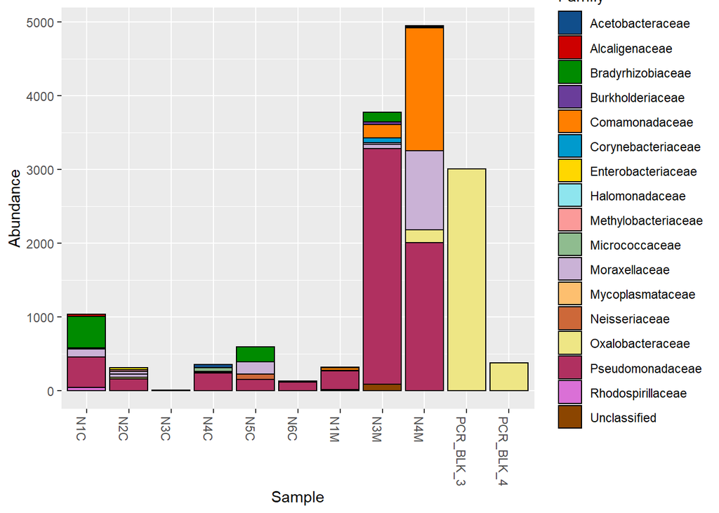

```r
#Plot absolute abundances to visualize differencies in the number of reads among samples
neg_plot2 <- plot_bar(neg_physeq1, fill = "Family")+
  scale_fill_manual(values = neg_palette)
neg_plot2$data$Sample <- factor(neg_plot2$data$Sample, levels = neg_layout)
neg_plot2
```

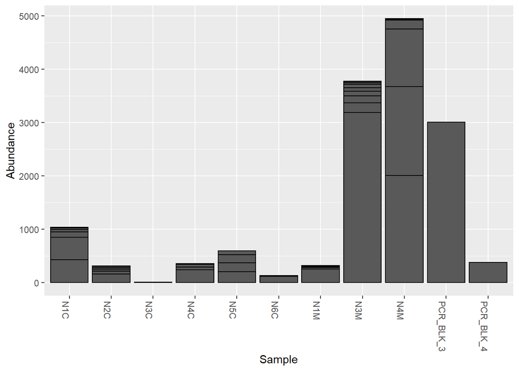

```r
#Plot reads number without taxonomical information:
neg_plot3 <- plot_bar(neg_physeq1)
neg_plot3$data$Sample <- factor(neg_plot3$data$Sample, levels = neg_layout)
neg_plot3
```

Further support for contaminants identification: Pattern of co-occurrence between contaminants and presence only in samples with high Ct values

Contaminants analysis:

```r
library(GUniFrac)
```

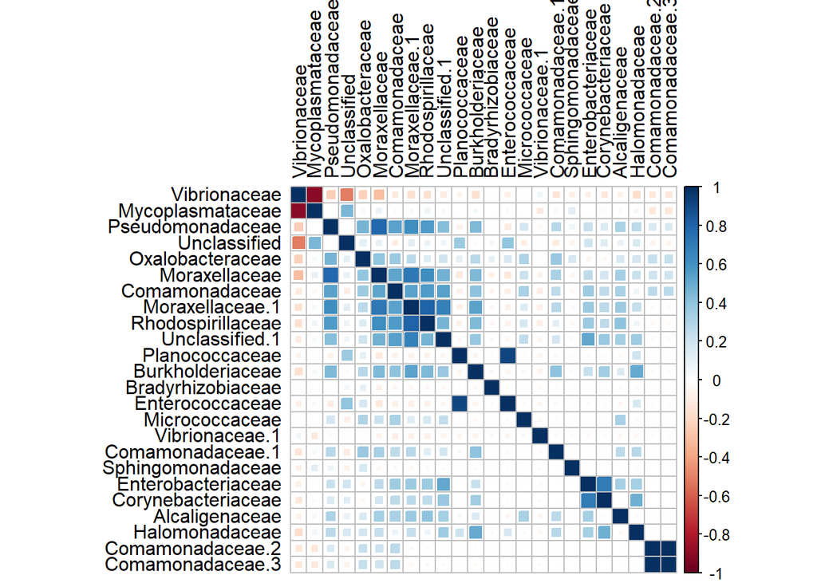

```r
#import original otutable with contaminants
otutable <- read.csv("Otutable_original.csv", row.names = 1)

#rarefy
otutable_reverse <- as.data.frame(t(otutable))
otutable_rarefied <- Rarefy(otutable_reverse, depth = 4000)
otu <- as.data.frame(otutable_rarefied$otu.tab.rff)
otutable <- as.data.frame(t(otu))
rm(otu, otutable_reverse, otutable_rarefied)

#remove empty rows
temp1 <- otutable[rowSums(otutable) > 0, ]
otutable <- temp1
rm(temp1)

#create a reduced otutable for plotting the heatmap
#select the first 20 OTUs:
otutable_reduced <- otutable[1:20,] #select the first 20 OTUs
#select specific OTUs (those present in the negative controls):
otutable_reduced <- rbind(otutable_reduced, otutable["OTU22",])
otutable_reduced <- rbind(otutable_reduced, otutable["OTU28",])
otutable_reduced <- rbind(otutable_reduced, otutable["OTU29",])
otutable_reduced <- rbind(otutable_reduced, otutable["OTU41",])
otutable_reduced <- rbind(otutable_reduced, otutable["OTU43",])
otutable_reduced <- rbind(otutable_reduced, otutable["OTU59",])
otutable_reduced <- rbind(otutable_reduced, otutable["OTU68",])
otutable_reduced <- rbind(otutable_reduced, otutable["OTU85",])
otutable_reduced <- rbind(otutable_reduced, otutable["OTU87",])
otutable_reduced <- rbind(otutable_reduced, otutable["OTU97",])
otutable_reduced <- rbind(otutable_reduced, otutable["OTU124",])
otutable_reduced <- na.omit(otutable_reduced) #becouse some OTus were removed by the rarefaction process
#remove mitochondria
otutable_reduced <- as.data.frame(t(otutable_reduced))
otutable_reduced$OTU8 <- NULL
otutable_reduced$OTU17 <- NULL
otutable_reduced <- as.data.frame(t(otutable_reduced))

#add taxonomy information
taxa <- read.csv("OTUs_Taxonomy.csv", row.names = 1)
test <- merge(otutable_reduced, taxa, by = "row.names", sort = F)
taxa <- test
row.names(taxa) <- make.names(taxa$Family, unique=TRUE)
row.names(otutable_reduced) <- make.names(taxa$Family, unique=TRUE)
rm(test, taxa)

#test correlation and create an heatmap
library(corrplot)
library(psych)
corr_table <- cor(t(otutable_reduced), method = "spearman")
corrplot(corr_table, method = "square",  tl.col = "black")
```

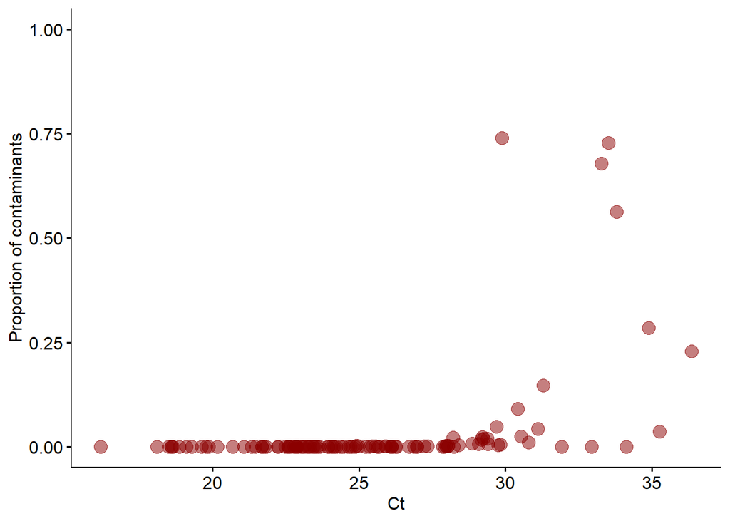

```r
# Calculate significance and R values for each correlation:
corr_matrix <- (corr.test(corr_table))
spearmann_table <- corr_matrix[[1]]

otutable_contaminants <- rbind(otutable["OTU3",], otutable["OTU5",], otutable["OTU6",],
                               otutable["OTU7",], otutable["OTU9",], otutable["OTU10",],
                               otutable["OTU11",], otutable["OTU13",], otutable["OTU14",],
                               otutable["OTU16",], otutable["OTU19",],
                               otutable["OTU22",], otutable["OTU28",], otutable["OTU29",],
                               otutable["OTU41",], otutable["OTU43",], otutable["OTU59",],
                               otutable["OTU68",], otutable["OTU85",], otutable["OTU87",],
                               otutable["OTU97",], otutable["OTU124",])
otutable_contaminants <- na.omit(otutable_contaminants)
contaminants.prop <- as.data.frame(colSums(otutable_contaminants)/4000)
colnames(contaminants.prop) <- c("contaminants")
contaminants.prop <- as.data.frame(t(contaminants.prop))
aliivibrio.prop <- otutable["OTU1",]/4000
mycoplasma.prop <- otutable["OTU2",]/4000
otu.prop <- rbind(aliivibrio.prop, mycoplasma.prop, contaminants.prop)
rm(aliivibrio.prop, mycoplasma.prop, contaminants.prop)
otu.prop <- as.data.frame(t(otu.prop))
Cts <- read.csv("Ct_values.csv", row.names = 1)
merged <- merge(otu.prop, Cts, by = "row.names")

#Create a plot for the contaminants
library(ggplot2)
library(ggpubr)
contaminants.corr.plot <- ggscatter(merged, x = "Ct..dR.", y = "contaminants", color = "red4",
                                    size = 4, alpha = 0.5, ylim = c(0, 1),
                           # add = "reg.line",
                           conf.int = TRUE, cor.method = "spearman",
                           #label.x.npc = "right", label.y.npc = "top",
                           cor.coef.coord = c(20, 1),
                           xlab = "Ct", ylab = "Proportion of contaminants")

contaminants.corr.plot
```

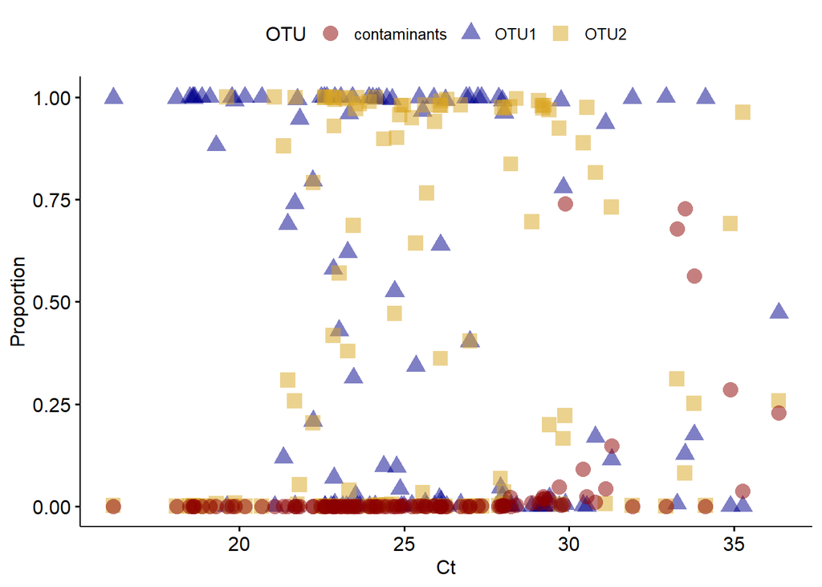

```r
#Create a plot for the first two OTUs and the contaminants
aliivibrio <- as.data.frame(cbind(merged$Row.names, merged$OTU1, merged$Ct..dR.))
aliivibrio$otu <- c("OTU1")
mycoplamsa <- as.data.frame(cbind(merged$Row.names, merged$OTU2, merged$Ct..dR.))
mycoplamsa$otu <- c("OTU2")
contaminants <- as.data.frame(cbind(merged$Row.names, merged$contaminants, merged$Ct..dR.))
contaminants$otu <- c("contaminants")
ct_plot_input_file <- rbind(aliivibrio, mycoplamsa, contaminants)
colnames(ct_plot_input_file) <- c("Sample", "Proportion", "Ct", "OTU")
write.csv(ct_plot_input_file, file = "ct_plot_input_file.csv")
ct_plot_input_file <- read.csv("ct_plot_input_file.csv", row.names = 1)

#plot
ct_plot <- ggscatter(ct_plot_input_file, x = "Ct", y = "Proportion", color = "OTU", shape = "OTU",
                        palette = c("red4", "darkblue", "goldenrod"),
                        size = 4,
                        # add = "reg.line",
                        conf.int = TRUE,
                        #cor.coef = TRUE, cor.method = "spearman",
                        #label.x.npc = "right", label.y.npc = "top",
                        cor.coef.coord = c(20, 1),
                        xlab = "Ct", ylab = "Proportion",
                        alpha = 0.5)

ct_plot
```

After identification the contaminants were manually removed along with mitochondia and chloroplast

Rarefaction procedure of the filtered otu table:

```r
library(GUniFrac)

#import the otutable without contaminants
otutable <- read.csv("Otutable_filtered.csv", row.names = 1)

#rarefy
otutable_reverse <- as.data.frame(t(otutable))
otutable_rarefied <- Rarefy(otutable_reverse, depth = 4000)
otu <- as.data.frame(otutable_rarefied$otu.tab.rff)
otutable <- as.data.frame(t(otu))
rm(otu, otutable_reverse, otutable_rarefied)
empty_row_removed <- otutable[which(rowSums(otutable) > 0), ]
otutable <- empty_row_removed
rm(empty_row_removed)
```

Alpha diversity analysis - Hilldiv:

```r
library(hilldiv)
otutable <- read.csv("Otutable_rarefied.csv", row.names = 1)
sampleinfo <- read.csv("Gropus_info_file.csv", row.names = 1)
hill_div(otutable, qvalue = 0) # samples richness
```

```
## X26CH X28CS X25MH X13MS X76CH X70CS X51MH X48MS X22CS X34MS X08MS X12MS X15CS
##     1     2     2     2     6     1     2     6     2     1     2     3     1
## X39MS X04CS X70MS X01MS X69MS X34CS X57MH X44CH X41MS X66CS X62MS X39CS X22MS
##     1     3     1     1     2     1     1     3     2     2     8     1     1
## X72CH X72MH X08CS X41CS X58MH X43CH X73CS X28MS X44MH X01CS X53MS X15MS X77MS
##     5     1     4     2     2     3     4     1     1     1     3     1     2
## X79CH X04MS X62CS X25CH X69CS X50MH X55CH X78MH X56MH X49CS X23CS X65MS X79MH
##     2     4     4     3     2     1    12     2     2     2     4     2     2
## X23MS X68CH X12CS X02CH X77CS X75CS X76MH X67CH X31MH X53CS X26MH X10CS X59MS
##     2     2     5     2     2     2     2    11     6     4     2     2     2
## X03CS X68MH X13CS X10MS X64CS X35CH X31CH X60MH X16CS X60CH X32CH X11MH X37CH
##     1     1     4     6     2     3     2     2     2     2     2     3     2
## X52CH X24CH X21CS X74CH X47CH X35MH X45CS X36CH X29CH X11CH X27MH X20MS X40MH
##     3     2     6     8     2     3    21     6     2     2     2     2     2
## X27CH X54CH X30CH X09CH X19CS X19MS X18CH X06CH X20CS X40CH X17CS X29MH X61CS
##     1     1     1     1     3     6     2     1     1     3     1     3     3
## X54MH X38CS X37MH X14CH X09MH X38MS X42CS X05CH X05MH
##     1     1     5     2     1     2     1     1    10
```

```r
hill_div(otutable, qvalue = 1) # samples shannon index
```

```
##    X26CH    X28CS    X25MH    X13MS    X76CH    X70CS    X51MH    X48MS
## 1.000000 1.016094 1.037360 1.020633 1.787823 1.000000 1.002326 1.191008
##    X22CS    X34MS    X08MS    X12MS    X15CS    X39MS    X04CS    X70MS
## 1.012941 1.000000 1.009652 1.145899 1.000000 1.000000 1.012282 1.000000
##    X01MS    X69MS    X34CS    X57MH    X44CH    X41MS    X66CS    X62MS
## 1.000000 1.002326 1.000000 1.000000 1.048864 1.002326 1.201443 1.149056
##    X39CS    X22MS    X72CH    X72MH    X08CS    X41CS    X58MH    X43CH
## 1.000000 1.000000 1.883937 1.000000 1.040028 1.197764 1.004310 1.010283
##    X73CS    X28MS    X44MH    X01CS    X53MS    X15MS    X77MS    X79CH
## 1.993706 1.000000 1.000000 1.000000 1.012282 1.000000 1.009652 1.033341
##    X04MS    X62CS    X25CH    X69CS    X50MH    X55CH    X78MH    X56MH
## 1.012633 2.032907 1.660541 1.977542 1.000000 2.028259 1.055160 1.016094
##    X49CS    X23CS    X65MS    X79MH    X23MS    X68CH    X12CS    X02CH
## 1.047698 1.504718 1.006165 1.071836 1.009652 1.933287 1.440258 1.582562
##    X77CS    X75CS    X76MH    X67CH    X31MH    X53CS    X26MH    X10CS
## 1.920433 1.406717 1.006165 2.248347 1.618116 1.686043 1.034690 1.872799
##    X59MS    X03CS    X68MH    X13CS    X10MS    X64CS    X35CH    X31CH
## 1.051456 1.000000 1.000000 1.400034 1.561892 1.042591 1.181835 1.319082
##    X60MH    X16CS    X60CH    X32CH    X11MH    X37CH    X52CH    X24CH
## 1.122986 1.131177 1.104080 1.071836 1.071268 1.042591 1.020786 1.037360
##    X21CS    X74CH    X47CH    X35MH    X45CS    X36CH    X29CH    X11CH
## 1.081495 1.035540 1.006165 1.014002 1.842404 1.025511 1.022106 1.006165
##    X27MH    X20MS    X40MH    X27CH    X54CH    X30CH    X09CH    X19CS
## 1.002326 1.011316 1.006165 1.000000 1.000000 1.000000 1.000000 1.012000
##    X19MS    X18CH    X06CH    X20CS    X40CH    X17CS    X29MH    X61CS
## 1.033945 1.002326 1.000000 1.000000 1.010501 1.000000 1.020981 1.006646
##    X54MH    X38CS    X37MH    X14CH    X09MH    X38MS    X42CS    X05CH
## 1.000000 1.000000 1.038375 1.002326 1.000000 1.007939 1.000000 1.000000
##    X05MH
## 1.094541
```

```r
samples_richness <- div_test(otutable, qvalue = 0, hierarchy = sampleinfo)
richness <- samples_richness$data
samples_shannon <- div_test(otutable, qvalue = 1, hierarchy = sampleinfo)
shannon <- samples_shannon$data

r <- split(richness, richness$Group)
r_chb <- as.data.frame(r$CHB)
r_csb <- as.data.frame(r$CSB)
r_mhb <- as.data.frame(r$MHB)
r_msb <- as.data.frame(r$MSB)
r_cha <- as.data.frame(r$CHA)
r_csa <- as.data.frame(r$CSA)
r_mha <- as.data.frame(r$MHA)
r_msa <- as.data.frame(r$MSA)

#richness values for each group:
mean(r_chb$Value)
```

```
## [1] 2.052632
```

```r
sd(r_chb$Value)
```

```
## [1] 1.17727
```

```r
mean(r_csb$Value)
```

```
## [1] 2.368421
```

```r
sd(r_csb$Value)
```

```
## [1] 1.570935
```

```r
mean(r_mhb$Value)
```

```
## [1] 3.545455
```

```r
sd(r_mhb$Value)
```

```
## [1] 2.583162
```

```r
mean(r_msb$Value)
```

```
## [1] 2.333333
```

```r
sd(r_msb$Value)
```

```
## [1] 1.718249
```

```r
mean(r_cha$Value)
```

```
## [1] 4.615385
```

```r
sd(r_cha$Value)
```

```
## [1] 3.617975
```

```r
mean(r_csa$Value)
```

```
## [1] 3.714286
```

```r
sd(r_csa$Value)
```

```
## [1] 5.075258
```

```r
mean(r_mha$Value)
```

```
## [1] 1.538462
```

```r
sd(r_mha$Value)
```

```
## [1] 0.5188745
```

```r
mean(r_msa$Value)
```

```
## [1] 3.111111
```

```r
sd(r_msa$Value)
```

```
## [1] 2.315407
```

```r
e <- split(shannon, shannon$Group)
e_chb <- as.data.frame(e$CHB)
e_csb <- as.data.frame(e$CSB)
e_mhb <- as.data.frame(e$MHB)
e_msb <- as.data.frame(e$MSB)
e_cha <- as.data.frame(e$CHA)
e_csa <- as.data.frame(e$CSA)
e_mha <- as.data.frame(e$MHA)
e_msa <- as.data.frame(e$MSA)

#shannon index values and sd for each group:
mean(e_chb$Value)
```

```
## [1] 1.103407
```

```r
sd(e_chb$Value)
```

```
## [1] 0.1995926
```

```r
mean(e_csb$Value)
```

```
## [1] 1.132833
```

```r
sd(e_csb$Value)
```

```
## [1] 0.2428188
```

```r
mean(e_mhb$Value)
```

```
## [1] 1.085257
```

```r
sd(e_mhb$Value)
```

```
## [1] 0.1791312
```

```r
mean(e_msb$Value)
```

```
## [1] 1.054237
```

```r
sd(e_msb$Value)
```

```
## [1] 0.1451597
```

```r
mean(e_cha$Value)
```

```
## [1] 1.395439
```

```r
sd(e_cha$Value)
```

```
## [1] 0.4892215
```

```r
mean(e_csa$Value)
```

```
## [1] 1.453992
```

```r
sd(e_csa$Value)
```

```
## [1] 0.4297717
```

```r
mean(e_mha$Value)
```

```
## [1] 1.021452
```

```r
sd(e_mha$Value)
```

```
## [1] 0.03836999
```

```r
mean(e_msa$Value)
```

```
## [1] 1.047141
```

```r
sd(e_msa$Value)
```

```
## [1] 0.0721471
```

Staked barplot - microbial samples composition:

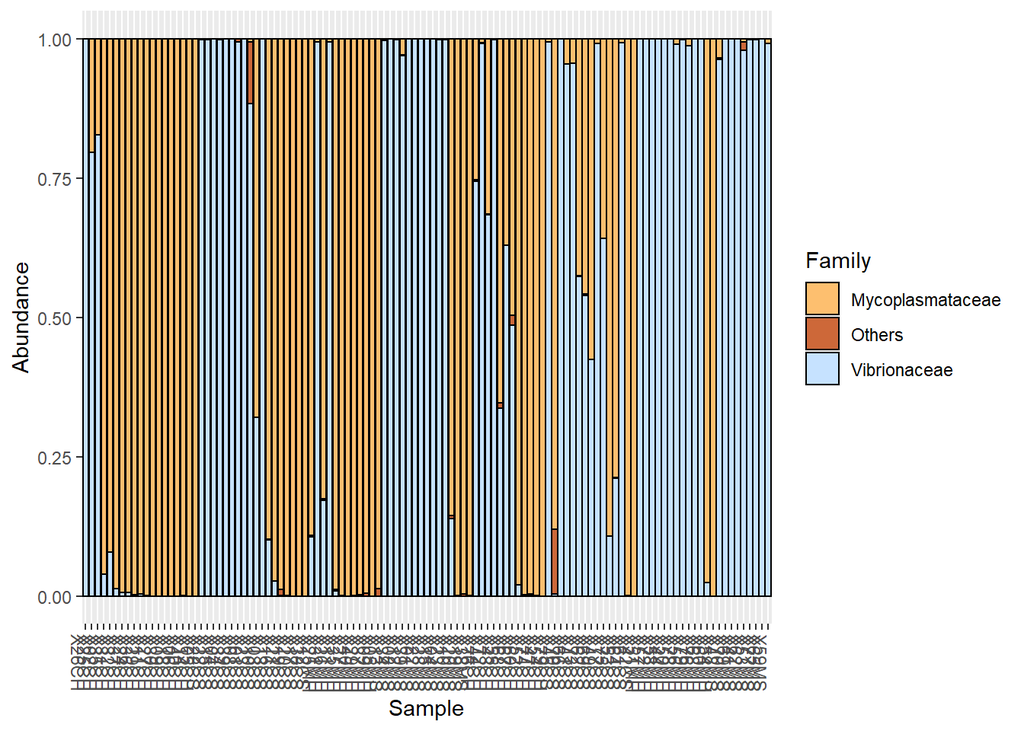

```r
library(phyloseq)
library(ggplot2)

otutable <- read.csv("Otutable_rarefied.csv", row.names = 1)
taxonomy <- read.csv("OTUs_Taxonomy.csv", header = TRUE, row.names = 1)
taxonomy <- as.matrix(taxonomy)

collapsed <- otutable
collapsed[3,] <- colSums(x = collapsed[3:65,])
otutable_collapsed <- collapsed[1:3,]
rownames(otutable_collapsed)[3]<-"Others"
rm(collapsed)

layout <- read.csv("Samples_barplot_layout.csv", row.names = 1)
layout <- c(as.character(layout$layout))
palette <- c("#FDBF6F", "sienna3", "slategray1")

otu = otu_table(otutable_collapsed, taxa_are_rows = TRUE)
tax = tax_table(taxonomy)
physeq <- phyloseq(otu, tax)
physeq2 = transform_sample_counts(physeq, function(x) x / sum(x))
samples_plot <- plot_bar(physeq2, fill = "Family") +
  scale_fill_manual(values = palette)
samples_plot$data$Sample <- factor(samples_plot$data$Sample, levels = layout)
samples_plot
```

Staked barplot & heatmap- microbial groups composition:

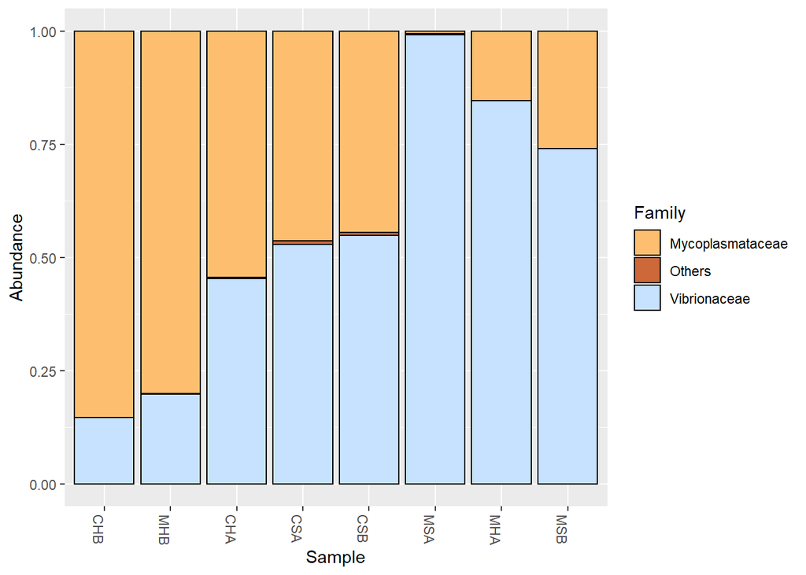

```r
library(phyloseq)
library(ggplot2)
library(vegan)

otutable <- read.csv("Otutable_rarefied.csv", row.names = 1)
taxonomy <- read.csv("OTUs_Taxonomy.csv", header = TRUE, row.names = 1)
taxonomy <- as.matrix(taxonomy)

names <- read.csv("Gropus_info_file.csv", row.names = 1)
row.names(names) <- names$Sample
v <- names$Groups
v <- as.vector(v)
colnames(otutable) <- v
temp1 <- t(otutable)
#merge rows with the same name
temp2 <- by(temp1, INDICES = row.names(temp1), FUN=colSums)
otutable <- as.data.frame(do.call(cbind,temp2))
rm(temp1, temp2, v)

#Staked barplot
collapsed <- otutable
collapsed[3,] <- colSums(x = collapsed[3:65,])
otutable_collapsed <- collapsed[1:3,]
rownames(otutable_collapsed)[3]<-"Others"
rm(collapsed)

layout1 <- c("CHB", "CSB", "MHB", "MSB", "CHA", "CSA", "MHA", "MSA")
layout2 <- c("CHB", "MHB", "CHA", "CSA", "CSB", "MSA", "MHA", "MSB") #jaccard beta diversity order
palette <- c("#FDBF6F", "sienna3", "slategray1")

otu = otu_table(otutable_collapsed, taxa_are_rows = TRUE)
tax = tax_table(taxonomy)
physeq <- phyloseq(otu, tax)
physeq2 = transform_sample_counts(physeq, function(x) x / sum(x))
groups_plot <- plot_bar(physeq2, fill = "Family") +
  scale_fill_manual(values = palette)
groups_plot$data$Sample <- factor(groups_plot$data$Sample, levels = layout2)
groups_plot
```

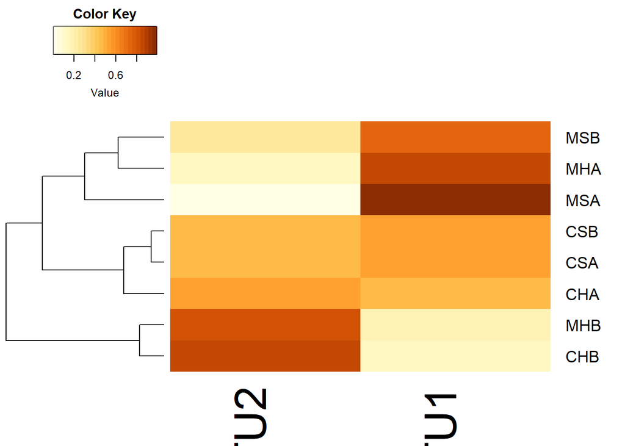

```r
# heatmap
library(gplots)
library(RColorBrewer)

inverted_otutable <- t(otutable)
#trasform raw counts to proportions
data.prop <- inverted_otutable/rowSums(inverted_otutable)
coul <- colorRampPalette(brewer.pal(8, "YlOrBr"))(25)
#calculate dendrogram
data.dist <- vegdist(data.prop, method = "jaccard")
row.clus <- hclust(data.dist, "aver")
heatmap.2(data.prop[, 1:2], scale = "none", col = coul,
          trace = "none", density.info = "none",
          Rowv = as.dendrogram(row.clus),
          dendrogram = c("row"))
```

Metadata wrangling (filtering out removed samples):

```r
otutable <- read.csv("Otutable_rarefied.csv", row.names = 1)
metadata <- read.csv("Metadata_original.csv", row.names = 1, header = T)
samples <- colnames(otutable)
meta <- subset(metadata, select = samples)
rm(metadata, samples)
meta <- as.data.frame(t(meta))
write.csv(meta, file = "Metadata_filtered.csv")
```

PERMANOVA - adonis (samples before treatment):

```r
library(vegan)

otutable <- read.csv("Otutable_rarefied.csv", row.names = 1)
meta <- read.csv("Metadata_filtered.csv", row.names = 1, header = T)
meta_before <- meta[which(meta$Treatment == "B"),]

#rename columns
names <- read.csv("Gropus_info_file.csv", row.names = 1)
row.names(names) <- names$Sample
v <- names$Groups
v <- as.vector(v)
colnames(otutable) <- v
rm(v)

#remove CHA
columns <- colnames(otutable)
count <- 0
for (i in columns){
  if (i == "CHA")
    count <- count +1
}
for (i in 1:count){
  otutable$CHA <- NULL
}

#remove CSA
columns <- colnames(otutable)
count <- 0
for (i in columns){
  if (i == "CSA")
    count <- count +1
}
for (i in 1:count){
  otutable$CSA <- NULL
}

#remove MHA
columns <- colnames(otutable)
count <- 0
for (i in columns){
  if (i == "MHA")
    count <- count +1
}
for (i in 1:count){
  otutable$MHA <- NULL
}

#remove MSA
columns <- colnames(otutable)
count <- 0
for (i in columns){
  if (i == "MSA")
    count <- count +1
}
for (i in 1:count){
  otutable$MSA <- NULL
}
otutable <- as.data.frame(t(otutable))
meta_before$Aliivibrio <- otutable$OTU1
meta_before$Mycoplasma <- otutable$OTU2

adonis(otutable ~ Groups, data = meta_before, permutations = 999, method = "jaccard")
```

```
##
## Call:
## adonis(formula = otutable ~ Groups, data = meta_before, permutations = 999,      method = "jaccard")
##
## Permutation: free
## Number of permutations: 999
##
## Terms added sequentially (first to last)
##
##           Df SumsOfSqs MeanSqs F.Model      R2 Pr(>F)
## Groups     3    3.8286 1.27621  6.8111 0.25404  0.001 ***
## Residuals 60   11.2424 0.18737         0.74596
## Total     63   15.0710                 1.00000
## ---
## Signif. codes:  0 '***' 0.001 '**' 0.01 '*' 0.05 '.' 0.1 ' ' 1
```

```r
adonis(otutable ~ Health_status, data = meta_before, permutations = 999, method = "jaccard")
```

```
##
## Call:
## adonis(formula = otutable ~ Health_status, data = meta_before,      permutations = 999, method = "jaccard")
##
## Permutation: free
## Number of permutations: 999
##
## Terms added sequentially (first to last)
##
##               Df SumsOfSqs MeanSqs F.Model      R2 Pr(>F)
## Health_status  1    3.4981  3.4981  18.741 0.23211  0.001 ***
## Residuals     62   11.5729  0.1867         0.76789
## Total         63   15.0710                 1.00000
## ---
## Signif. codes:  0 '***' 0.001 '**' 0.01 '*' 0.05 '.' 0.1 ' ' 1
```

```r
adonis(otutable ~ Tissue_type, data = meta_before, permutations = 999, method = "jaccard")
```

```
##
## Call:
## adonis(formula = otutable ~ Tissue_type, data = meta_before,      permutations = 999, method = "jaccard")
##
## Permutation: free
## Number of permutations: 999
##
## Terms added sequentially (first to last)
##
##             Df SumsOfSqs MeanSqs F.Model      R2 Pr(>F)
## Tissue_type  1    0.4048 0.40483  1.7114 0.02686  0.167
## Residuals   62   14.6662 0.23655         0.97314
## Total       63   15.0710                 1.00000
```

```r
adonis(otutable ~ Weight, data = meta_before, permutations = 999, method = "jaccard")
```

```
##
## Call:
## adonis(formula = otutable ~ Weight, data = meta_before, permutations = 999,      method = "jaccard")
##
## Permutation: free
## Number of permutations: 999
##
## Terms added sequentially (first to last)
##
##           Df SumsOfSqs MeanSqs F.Model     R2 Pr(>F)
## Weight     1    2.6058 2.60581  12.961 0.1729  0.001 ***
## Residuals 62   12.4652 0.20105         0.8271
## Total     63   15.0710                 1.0000
## ---
## Signif. codes:  0 '***' 0.001 '**' 0.01 '*' 0.05 '.' 0.1 ' ' 1
```

```r
adonis(otutable ~ K_Factor, data = meta_before, permutations = 999, method = "jaccard")
```

```
##
## Call:
## adonis(formula = otutable ~ K_Factor, data = meta_before, permutations = 999,      method = "jaccard")
##
## Permutation: free
## Number of permutations: 999
##
## Terms added sequentially (first to last)
##
##           Df SumsOfSqs MeanSqs F.Model      R2 Pr(>F)
## K_Factor   1    1.1783 1.17830  5.2585 0.07818   0.03 *
## Residuals 62   13.8927 0.22408         0.92182
## Total     63   15.0710                 1.00000
## ---
## Signif. codes:  0 '***' 0.001 '**' 0.01 '*' 0.05 '.' 0.1 ' ' 1
```

```r
adonis(otutable ~ Tanks, data = meta_before, permutations = 999, method = "jaccard") #tank effect
```

```
##
## Call:
## adonis(formula = otutable ~ Tanks, data = meta_before, permutations = 999,      method = "jaccard")
##
## Permutation: free
## Number of permutations: 999
##
## Terms added sequentially (first to last)
##
##           Df SumsOfSqs MeanSqs F.Model     R2 Pr(>F)
## Tanks      9    5.3759 0.59732  3.3269 0.3567  0.002 **
## Residuals 54    9.6952 0.17954         0.6433
## Total     63   15.0710                 1.0000
## ---
## Signif. codes:  0 '***' 0.001 '**' 0.01 '*' 0.05 '.' 0.1 ' ' 1
```

Spearman correlation plots (all samples):

```r
library(ggplot2)
library(ggpubr)

otutable <- read.csv("Otutable_rarefied.csv", row.names = 1)
meta <- read.csv("Metadata_filtered.csv", row.names = 1, header = T)
otutable <- as.data.frame(t(otutable))
meta$Aliivibrio <- otutable$OTU1/4000
meta$Mycoplasma <- otutable$OTU2/4000

#Aliivibrio - Mycoplasma:
cor.test(meta$Aliivibrio, meta$Mycoplasma, method = "spearman")
```

```
##
##  Spearman's rank correlation rho
##
## data:  meta$Aliivibrio and meta$Mycoplasma
## S = 476240, p-value < 2.2e-16
## alternative hypothesis: true rho is not equal to 0
## sample estimates:
##        rho
## -0.9805049
```

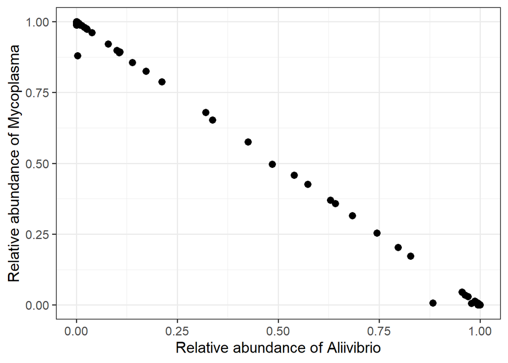

```r
ggplot(meta, aes(x=Aliivibrio, y=Mycoplasma)) +
  xlab("Relative abundance of Aliivibrio")+ ylab("Relative abundance of Mycoplasma") +
  geom_point(color='Black', size = 3) +
  theme_bw(base_size = 15) +
  coord_cartesian(ylim = c(0, 1))
```

```r
#Mycoplasma - Weight:
cor.test(meta$Weight, meta$Mycoplasma, method = "spearman")
```

```
##
##  Spearman's rank correlation rho
##
## data:  meta$Weight and meta$Mycoplasma
## S = 149420, p-value = 3.549e-05
## alternative hypothesis: true rho is not equal to 0
## sample estimates:
##       rho
## 0.3786164
```

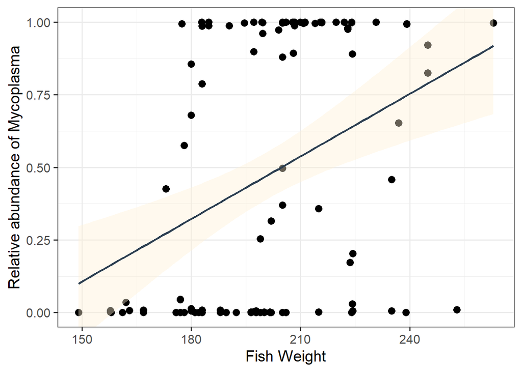

```r
ggplot(meta, aes(x=Weight, y=Mycoplasma)) +
  xlab("Fish Weight")+ ylab("Relative abundance of Mycoplasma") +
  geom_point(color='Black', size = 3) +
  geom_smooth(method=lm, se=T, fullrange=TRUE, color='#2C3E50', fill = "papayawhip")  +
  theme_bw(base_size = 15) +
  coord_cartesian(ylim = c(0, 1))
```

```r
#Aliivibrio - Weight:
cor.test(meta$Weight, meta$Aliivibrio, method = "spearman")
```

```
##
##  Spearman's rank correlation rho
##
## data:  meta$Weight and meta$Aliivibrio
## S = 329088, p-value = 5.905e-05
## alternative hypothesis: true rho is not equal to 0
## sample estimates:
##        rho
## -0.3685554
```

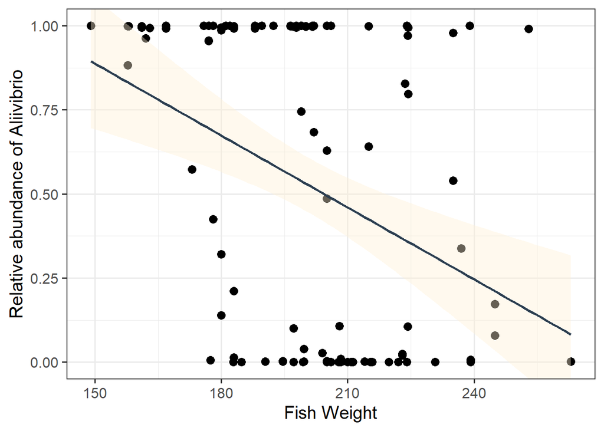

```r
ggplot(meta, aes(x=Weight, y=Aliivibrio)) +
  xlab("Fish Weight")+ ylab("Relative abundance of Aliivibrio") +
  geom_point(color='Black', size = 3) +
  geom_smooth(method=lm, se=T, fullrange=TRUE, color='#2C3E50', fill = "papayawhip")  +
  theme_bw(base_size = 15) +
  coord_cartesian(ylim = c(0, 1))
```

```r
#Mycoplasma - K Factor:
cor.test(meta$K_Factor, meta$Mycoplasma, method = "spearman")
```

```
##
##  Spearman's rank correlation rho
##
## data:  meta$K_Factor and meta$Mycoplasma
## S = 154598, p-value = 0.0001034
## alternative hypothesis: true rho is not equal to 0
## sample estimates:
##       rho
## 0.3570842
```

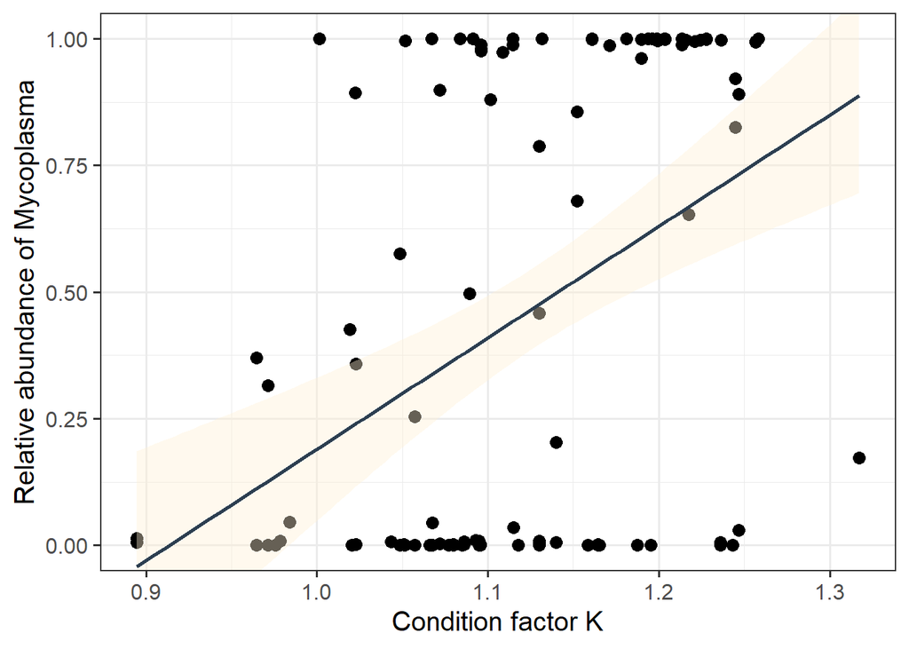

```r
ggplot(meta, aes(x=K_Factor, y=Mycoplasma)) +
  xlab("Condition factor K")+ ylab("Relative abundance of Mycoplasma") +
  geom_point(color='Black', size = 3) +
  geom_smooth(method=lm, se=T, fullrange=TRUE, color='#2C3E50', fill = "papayawhip")  +
  theme_bw(base_size = 15) +
  coord_cartesian(ylim = c(0, 1))
```

```r
#Aliivibrio - K Factor:
cor.test(meta$K_Factor, meta$Aliivibrio, method = "spearman")
```

```
##
##  Spearman's rank correlation rho
##
## data:  meta$K_Factor and meta$Aliivibrio
## S = 330785, p-value = 4.139e-05
## alternative hypothesis: true rho is not equal to 0
## sample estimates:
##        rho
## -0.3756119
```

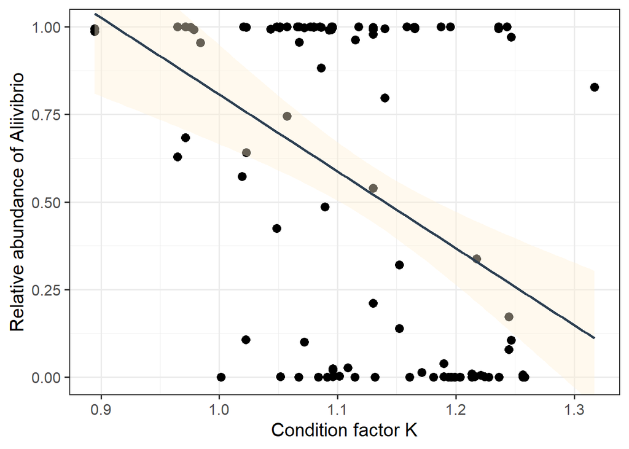

```r
ggplot(meta, aes(x=K_Factor, y=Aliivibrio)) +
  xlab("Condition factor K")+ ylab("Relative abundance of Aliivibrio") +
  geom_point(color='Black', size = 3) +
  geom_smooth(method=lm, se=T, fullrange=TRUE, color='#2C3E50', fill = "papayawhip")  +
  theme_bw(base_size = 15) +
  coord_cartesian(ylim = c(0, 1))
```

Spearman correlation plots (samples before treatment):

```r
library(ggplot2)
library(ggpubr)

otutable <- read.csv("Otutable_rarefied.csv", row.names = 1)
meta <- read.csv("Metadata_filtered.csv", row.names = 1, header = T)
meta_before <- meta[which(meta$Treatment == "B"),]

#rename columns
names <- read.csv("Gropus_info_file.csv", row.names = 1)
row.names(names) <- names$Sample
v <- names$Groups
v <- as.vector(v)
colnames(otutable) <- v
rm(v)

#remove CHA
columns <- colnames(otutable)
count <- 0
for (i in columns){
  if (i == "CHA")
    count <- count +1
}
for (i in 1:count){
  otutable$CHA <- NULL
}

#remove CSA
columns <- colnames(otutable)
count <- 0
for (i in columns){
  if (i == "CSA")
    count <- count +1
}
for (i in 1:count){
  otutable$CSA <- NULL
}

#remove MHA
columns <- colnames(otutable)
count <- 0
for (i in columns){
  if (i == "MHA")
    count <- count +1
}
for (i in 1:count){
  otutable$MHA <- NULL
}

#remove MSA
columns <- colnames(otutable)
count <- 0
for (i in columns){
  if (i == "MSA")
    count <- count +1
}
for (i in 1:count){
  otutable$MSA <- NULL
}
otutable <- as.data.frame(t(otutable))
meta_before$Aliivibrio <- otutable$OTU1/4000
meta_before$Mycoplasma <- otutable$OTU2/4000

#Mycoplasma - Weight:
cor.test(meta_before$Weight, meta_before$Mycoplasma, method = "spearman")
```

```
##
##  Spearman's rank correlation rho
##
## data:  meta_before$Weight and meta_before$Mycoplasma
## S = 25116, p-value = 0.0004642
## alternative hypothesis: true rho is not equal to 0
## sample estimates:
##       rho
## 0.4250108
```

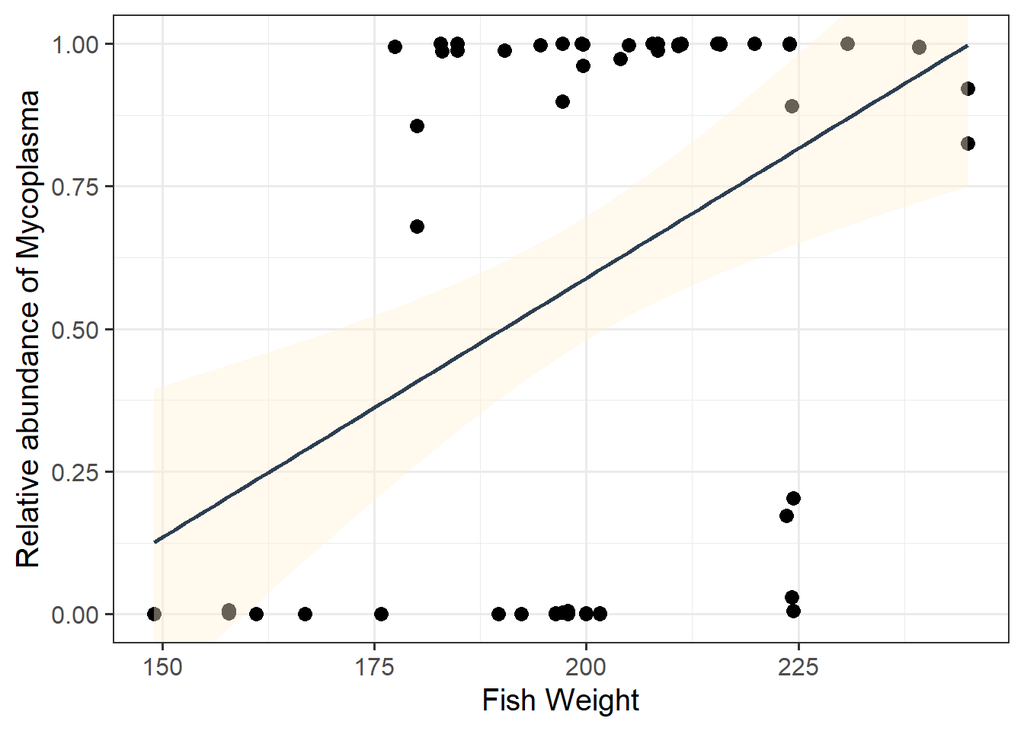

```r
ggplot(meta_before, aes(x=Weight, y=Mycoplasma)) +
  xlab("Fish Weight")+ ylab("Relative abundance of Mycoplasma") +
  geom_point(color='Black', size = 3) +
  geom_smooth(method=lm, se=T, fullrange=TRUE, color='#2C3E50', fill = "papayawhip")  +
  theme_bw(base_size = 15) +
  coord_cartesian(ylim = c(0, 1))
```

```r
#Aliivibrio - Weight:
cor.test(meta_before$Weight, meta_before$Aliivibrio, method = "spearman")
```

```
##
##  Spearman's rank correlation rho
##
## data:  meta_before$Weight and meta_before$Aliivibrio
## S = 63089, p-value = 0.0002349
## alternative hypothesis: true rho is not equal to 0
## sample estimates:
##        rho
## -0.4443433
```

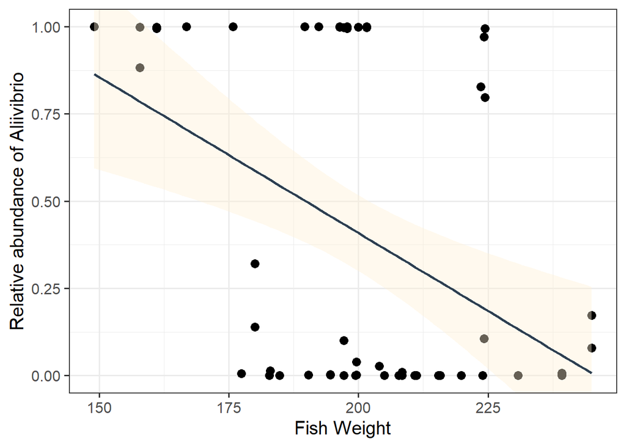

```r
ggplot(meta_before, aes(x=Weight, y=Aliivibrio)) +
  xlab("Fish Weight")+ ylab("Relative abundance of Aliivibrio") +
  geom_point(color='Black', size = 3) +
  geom_smooth(method=lm, se=T, fullrange=TRUE, color='#2C3E50', fill = "papayawhip")  +
  theme_bw(base_size = 15) +
  coord_cartesian(ylim = c(0, 1))
```

```r
#Mycoplasma - K Factor:
cor.test(meta_before$K_Factor, meta_before$Mycoplasma, method = "spearman")
```

```
##
##  Spearman's rank correlation rho
##
## data:  meta_before$K_Factor and meta_before$Mycoplasma
## S = 32064, p-value = 0.03367
## alternative hypothesis: true rho is not equal to 0
## sample estimates:
##       rho
## 0.2659342
```

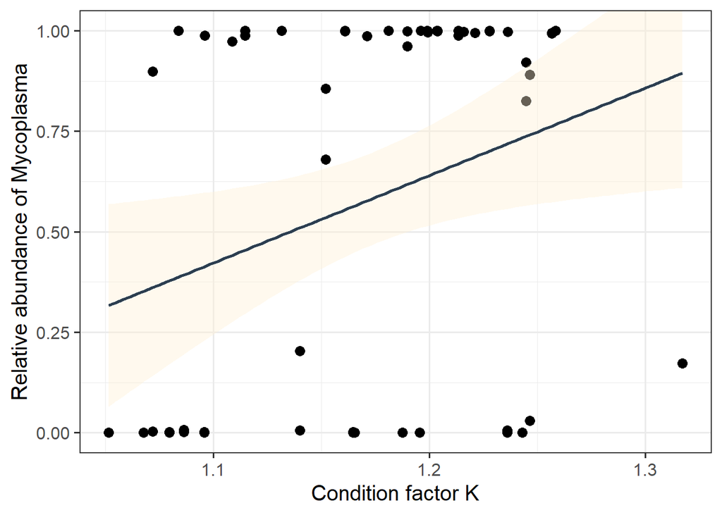

```r
ggplot(meta_before, aes(x=K_Factor, y=Mycoplasma)) +
  xlab("Condition factor K")+ ylab("Relative abundance of Mycoplasma") +
  geom_point(color='Black', size = 3) +
  geom_smooth(method=lm, se=T, fullrange=TRUE, color='#2C3E50', fill = "papayawhip")  +
  theme_bw(base_size = 15) +
  coord_cartesian(ylim = c(0, 1))
```

```r
#Aliivibrio - K Factor:
cor.test(meta_before$K_Factor, meta_before$Aliivibrio, method = "spearman")
```

```
##
##  Spearman's rank correlation rho
##
## data:  meta_before$K_Factor and meta_before$Aliivibrio
## S = 54851, p-value = 0.04138
## alternative hypothesis: true rho is not equal to 0
## sample estimates:
##        rho
## -0.2557404
```

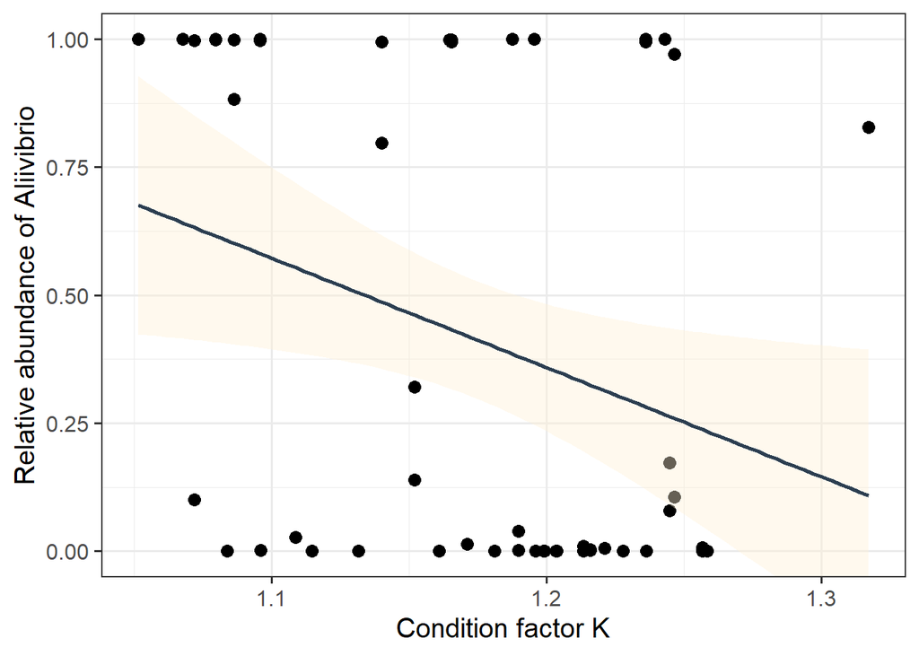

```r
ggplot(meta_before, aes(x=K_Factor, y=Aliivibrio)) +
  xlab("Condition factor K")+ ylab("Relative abundance of Aliivibrio") +
  geom_point(color='Black', size = 3) +
  geom_smooth(method=lm, se=T, fullrange=TRUE, color='#2C3E50', fill = "papayawhip")  +
  theme_bw(base_size = 15) +
  coord_cartesian(ylim = c(0, 1))
```

Healthy vs sick - (before treatment):

```r
otutable <- read.csv("Otutable_rarefied.csv", row.names = 1)
otutable <- as.data.frame(t(otutable))
meta <- read.csv("Metadata_filtered.csv", row.names = 1)
meta$Aliivibrio <- otutable$OTU1/4000
meta$Mycoplasma <- otutable$OTU2/4000

#split the dataframe (before vs after treatment)
before <- meta[which(meta$Treatment == "B"),]
after <- meta[which(meta$Treatment == "A"),]

#split healthy vs sick to compare vibrio and micoplasma abundances (only for before)
healthy <- before[which(before$Health_status == "H"),]
sick <- before[which(before$Health_status == "S"),]

shapiro.test(healthy$Aliivibrio)
```

```
##
##  Shapiro-Wilk normality test
##
## data:  healthy$Aliivibrio
## W = 0.51133, p-value = 7.074e-09
```

```r
shapiro.test(sick$Aliivibrio)
```

```
##
##  Shapiro-Wilk normality test
##
## data:  sick$Aliivibrio
## W = 0.66127, p-value = 1.318e-07
```

```r
shapiro.test(healthy$Mycoplasma)
```

```
##
##  Shapiro-Wilk normality test
##
## data:  healthy$Mycoplasma
## W = 0.51323, p-value = 7.414e-09
```

```r
shapiro.test(sick$Mycoplasma)
```

```
##
##  Shapiro-Wilk normality test
##
## data:  sick$Mycoplasma
## W = 0.65286, p-value = 1.003e-07
```

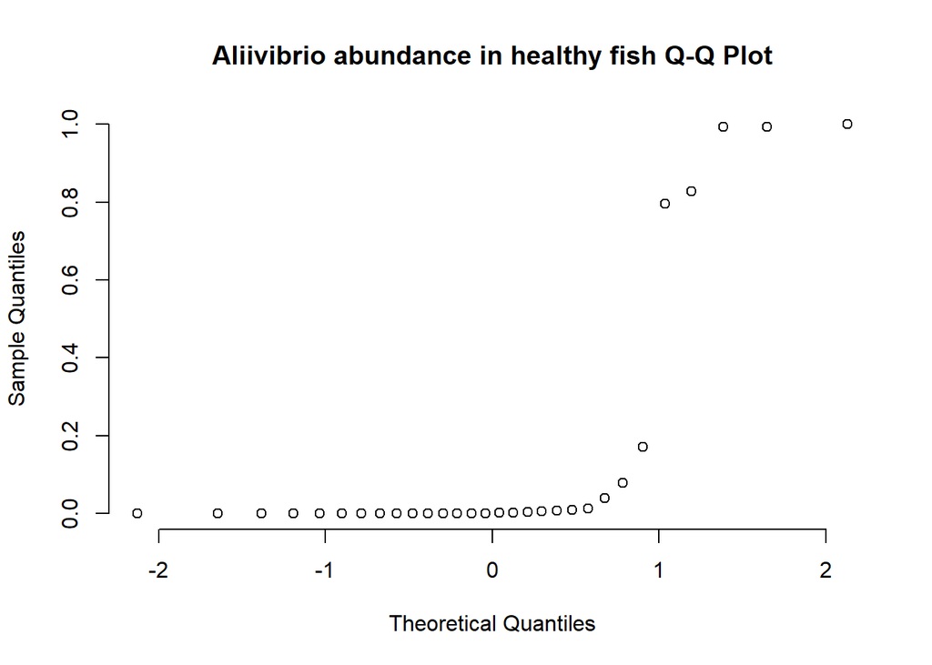

```r
#qqplot (to visualize normality)
qqnorm(healthy$Aliivibrio, pch = 1, frame = FALSE, main = "Aliivibrio abundance in healthy fish Q-Q Plot")
```

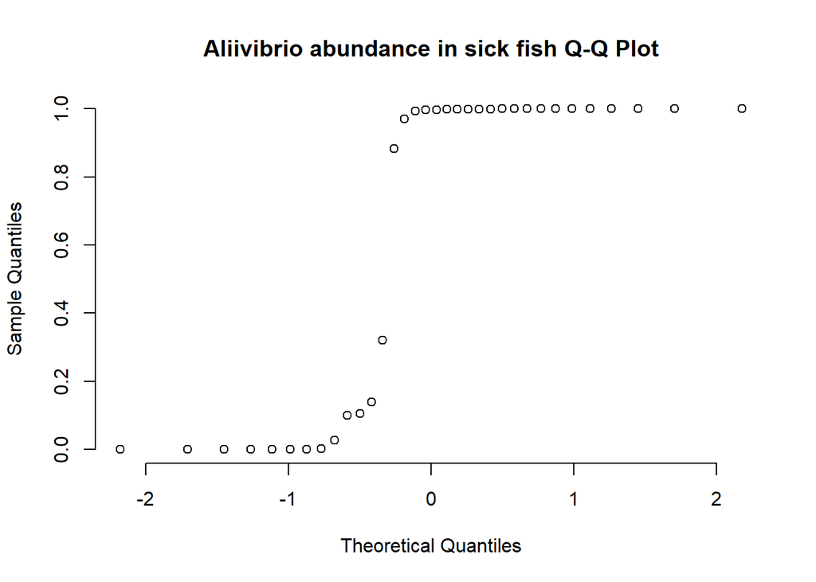

```r
qqnorm(sick$Aliivibri, pch = 1, frame = FALSE, main = "Aliivibrio abundance in sick fish Q-Q Plot")
```

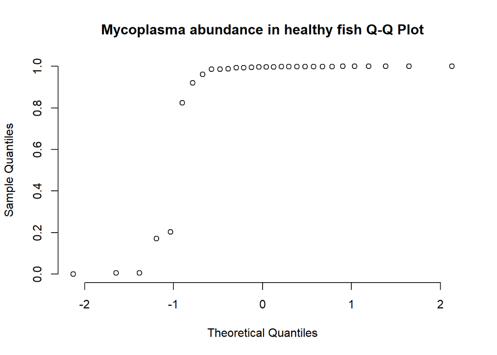

```r
qqnorm(healthy$Mycoplasma, pch = 1, frame = FALSE, main = "Mycoplasma abundance in healthy fish Q-Q Plot")
```

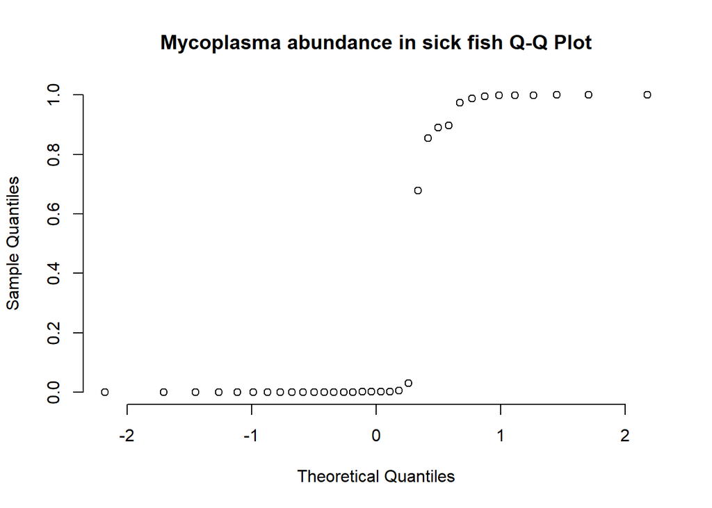

```r
qqnorm(sick$Mycoplasma, pch = 1, frame = FALSE, main = "Mycoplasma abundance in sick fish Q-Q Plot")
```

```r
#test if two samples have same variance (fisher's F test)
var.test(healthy$Aliivibrio, sick$Aliivibrio)
```

```
##
##  F test to compare two variances
##
## data:  healthy$Aliivibrio and sick$Aliivibrio
## F = 0.55646, num df = 29, denom df = 33, p-value = 0.1126
## alternative hypothesis: true ratio of variances is not equal to 1
## 95 percent confidence interval:
##  0.2734857 1.1513976
## sample estimates:
## ratio of variances
##          0.5564584
```

```r
var.test(healthy$Mycoplasma, sick$Mycoplasma)
```

```
##
##  F test to compare two variances
##
## data:  healthy$Mycoplasma and sick$Mycoplasma
## F = 0.55223, num df = 29, denom df = 33, p-value = 0.1081
## alternative hypothesis: true ratio of variances is not equal to 1
## 95 percent confidence interval:
##  0.2714098 1.1426579
## sample estimates:
## ratio of variances
##          0.5522346
```

```r
#Mycoplasma:
wilcox.test(healthy$Mycoplasma, sick$Mycoplasma) #p-value = 4.604e-05 (0.03) (there is a difference in the mean)
```

```
##
##  Wilcoxon rank sum test with continuity correction
##
## data:  healthy$Mycoplasma and sick$Mycoplasma
## W = 811, p-value = 4.604e-05
## alternative hypothesis: true location shift is not equal to 0
```

```r
mean(healthy$Mycoplasma) # mean = 0.834125
```

```
## [1] 0.834125
```

```r
sd(healthy$Mycoplasma) # sd = 0.3479495
```

```
## [1] 0.3479495
```

```r
mean(sick$Mycoplasma) # mean = 0.3623971
```

```
## [1] 0.3623971
```

```r
sd(sick$Mycoplasma) # sd = 0.4682248
```

```
## [1] 0.4682248
```

```r
#Aliivibrio:
wilcox.test(healthy$Aliivibrio, sick$Aliivibrio) #p-value = 0.0001271 (there is a difference in the mean)
```

```
##
##  Wilcoxon rank sum test with continuity correction
##
## data:  healthy$Aliivibrio and sick$Aliivibrio
## W = 230, p-value = 0.0001271
## alternative hypothesis: true location shift is not equal to 0
```

```r
mean(healthy$Aliivibrio) # mean = 0.1649
```

```
## [1] 0.1649
```

```r
sd(healthy$Aliivibrio) # sd = 0.3483487
```

```
## [1] 0.3483487
```

```r
mean(sick$Aliivibrio) # mean = 0.6331985
```

```
## [1] 0.6331985
```

```r
sd(sick$Aliivibrio) # sd = 0.4669796
```

```
## [1] 0.4669796
```

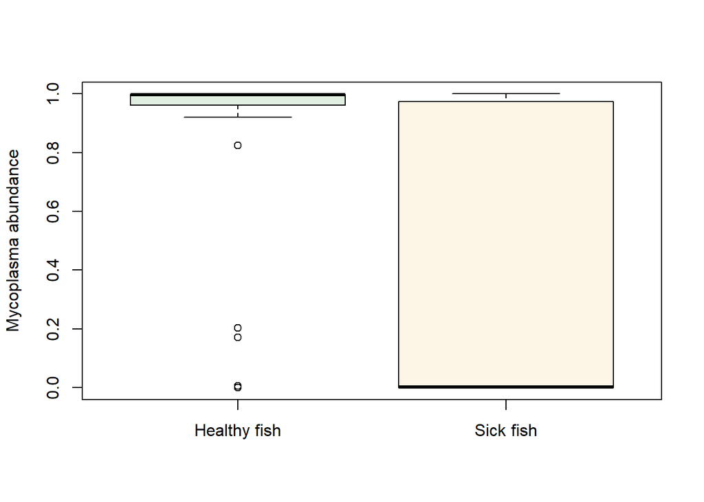

```r
#Mycoplasma boxplot:
boxplot(healthy$Mycoplasma, sick$Mycoplasma,
        ylab = c("Mycoplasma abundance"),
        ann = T,
        col = c("honeydew2", "oldlace"),
        names = c("Healthy fish", "Sick fish"))
```

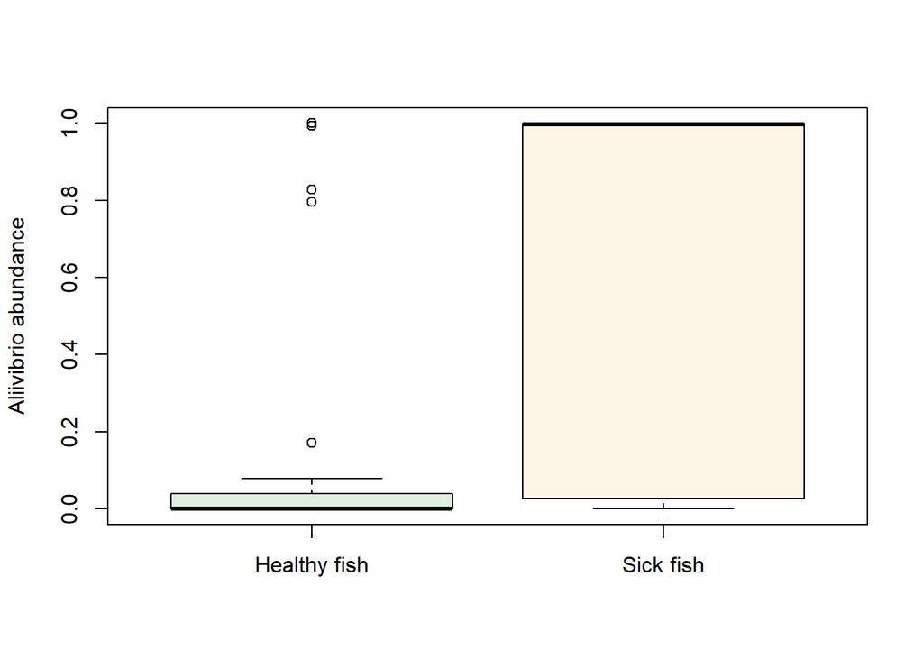

```r
#Aliivibrio boxplot:
boxplot(healthy$Aliivibrio, sick$Aliivibrio,
        ylab = c("Aliivibrio abundance"),
        ann = T,
        col = c("honeydew2", "oldlace"),
        names = c("Healthy fish", "Sick fish"))
```

Differencies in weight:

```r
# import metadata meta
meta <- read.csv("Metadata_filtered.csv", row.names = 1)
meta$Aliivibrio <- otutable$OTU1/4000
meta$Mycoplasma <- otutable$OTU2/4000

#split the dataframe (before vs after treatment)
before <- meta[which(meta$Treatment == "B"),]

#split the dataframe (high Aliivibrio vs high Mycoplamsa)
high_vibrio <- before[which(before$Aliivibrio >= 0.8),]
high_myco <- before[which(before$Mycoplasma >= 0.8),]

#normality
shapiro.test(high_vibrio$Weight) # p-value = 0.05632
```

```
##
##  Shapiro-Wilk normality test
##
## data:  high_vibrio$Weight
## W = 0.9218, p-value = 0.05632
```

```r
shapiro.test(high_myco$Weight) # p-value = 0.2448
```

```
##
##  Shapiro-Wilk normality test
##
## data:  high_myco$Weight
## W = 0.96265, p-value = 0.2448
```

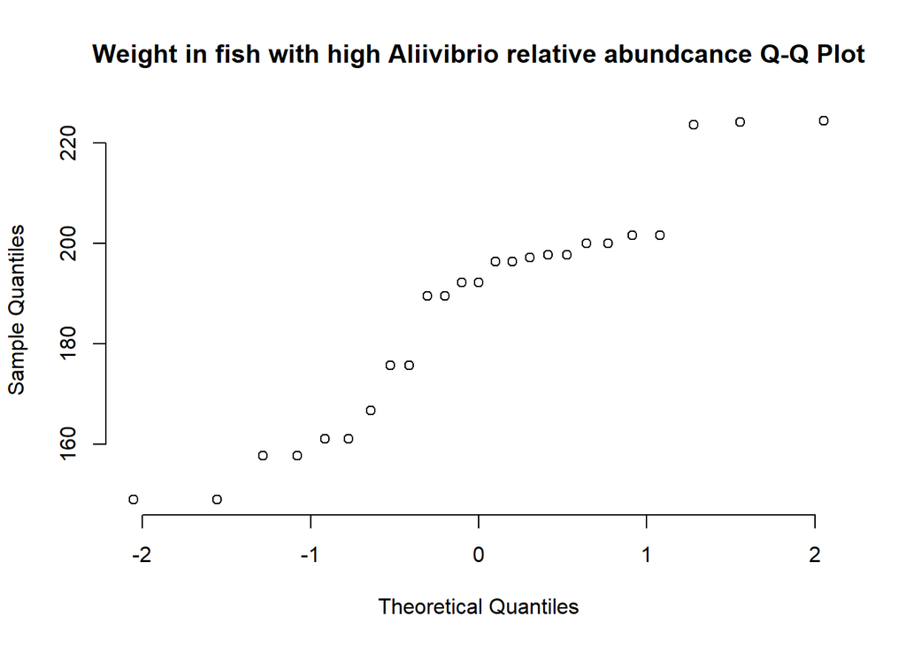

```r
#qqplots
qqnorm(high_vibrio$Weight, pch = 1, frame = FALSE, main = "Weight in fish with high Aliivibrio relative abundcance Q-Q Plot")
```

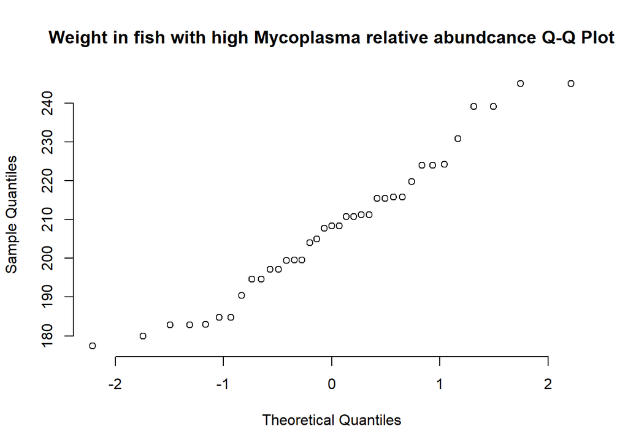

```r
qqnorm(high_myco$Weight, pch = 1, frame = FALSE, main = "Weight in fish with high Mycoplasma relative abundcance Q-Q Plot")
```

```r
#test if two samples have same variance (fisher's F test)
var.test(high_vibrio$Weight, high_myco$Weight) # p-value = 0.2795
```

```
##
##  F test to compare two variances
##
## data:  high_vibrio$Weight and high_myco$Weight
## F = 1.4816, num df = 24, denom df = 36, p-value = 0.2795
## alternative hypothesis: true ratio of variances is not equal to 1
## 95 percent confidence interval:
##  0.7229601 3.2111960
## sample estimates:
## ratio of variances
##           1.481646
```

```r
# Welch Two Sample t-test: (normality and equality of variance are respected, sample size different)
t.test(high_vibrio$Weight, high_myco$Weight) #  p-value = 0.000478 (they are differet!)
```

```
##
##  Welch Two Sample t-test
##
## data:  high_vibrio$Weight and high_myco$Weight
## t = -3.7688, df = 44.685, p-value = 0.000478
## alternative hypothesis: true difference in means is not equal to 0
## 95 percent confidence interval:
##  -31.29095  -9.49175
## sample estimates:
## mean of x mean of y
##  187.1600  207.5514
```

```r
mean(high_vibrio$Weight) #187.16
```

```
## [1] 187.16
```

```r
sd(high_vibrio$Weight) #22.41967
```

```
## [1] 22.41967
```

```r
mean(high_myco$Weight) #207.5514
```

```
## [1] 207.5514
```

```r
sd(high_myco$Weight) #18.41861
```

```
## [1] 18.41861
```

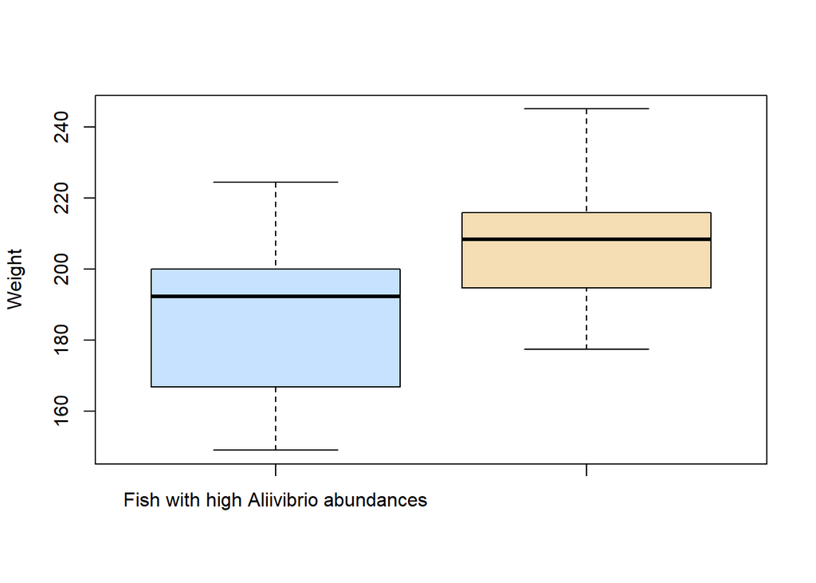

```r
boxplot(high_vibrio$Weight, high_myco$Weight,
        ylab = c("Weight"),
        ann = T,
        col = c("slategray1", "wheat"), #aliceblue
        names = c("Fish with high Aliivibrio abundances", "Fish with high Mycoplasma abundances"))
```

```r
library(ggplot2)
library(dplyr)
library(car)
otutable <- read.csv("Otutable_rarefied.csv", row.names = 1)
otutable <- as.data.frame(t(otutable))
meta <- read.csv("Metadata_filtered.csv", row.names = 1)
meta$Aliivibrio <- otutable$OTU1/4000
meta$Mycoplasma <- otutable$OTU2/4000
Cts <- read.csv("Ct_values.csv", row.names = 1)
colnames(Cts) <- c("Sample", "Ct")
merged_meta <- merge(meta, Cts, by = "Sample")
```

Introduce a Ct values correction to each sample:

corrected ct value = ct value + (log2(a/m) * Aliivibrio relative abundance) a = Aliivibrio genus median 16S rRNA gene copy number (a = 12) m = Mycoplasma genus median 16S rRNA gene copy number (m = 2)

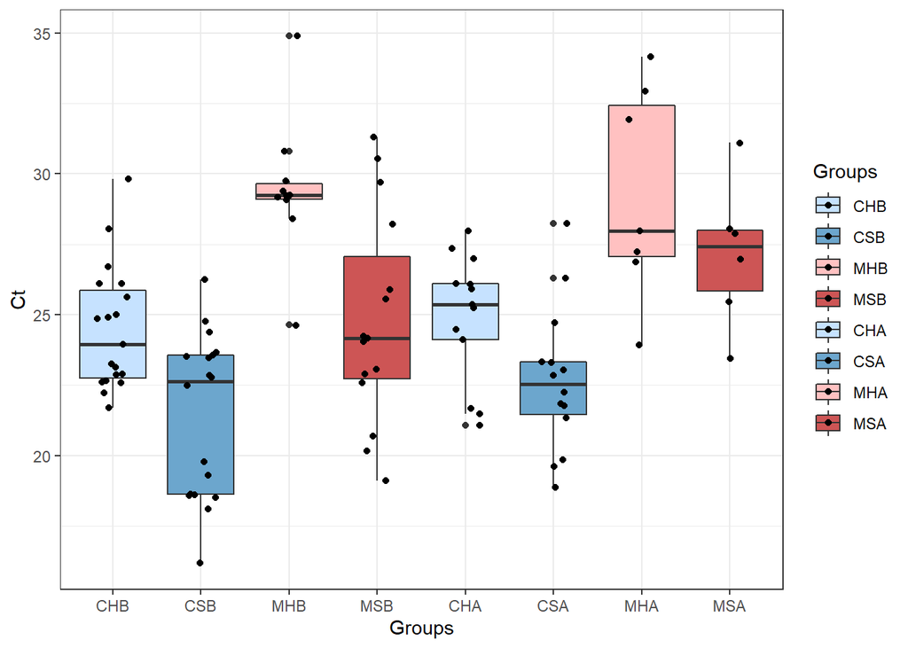

```r
merged_meta$Ct_corr <- merged_meta$Ct + (merged_meta$Aliivibrio * 2.58)

chb <- merged_meta[which(merged_meta$Groups == "CHB"),]
csb <- merged_meta[which(merged_meta$Groups == "CSB"),]
mhb <- merged_meta[which(merged_meta$Groups == "MHB"),]
msb <- merged_meta[which(merged_meta$Groups == "MSB"),]
cha <- merged_meta[which(merged_meta$Groups == "CHA"),]
csa <- merged_meta[which(merged_meta$Groups == "CSA"),]
mha <- merged_meta[which(merged_meta$Groups == "MHA"),]
msa <- merged_meta[which(merged_meta$Groups == "MSA"),]

merged_meta %>%
  arrange(Ct) %>%
  mutate(Groups = factor(Groups, levels=c("CHB", "CSB", "MHB", "MSB", "CHA", "CSA", "MHA", "MSA"))) %>%
  ggplot(aes(x = Groups, y = Ct, fill= Groups)) +
  geom_boxplot() +
  geom_jitter(width = 0.18) +
  theme_bw() +
  scale_fill_manual(values=c("slategray1", "skyblue3", "rosybrown1", "indianred3", "slategray1", "skyblue3", "rosybrown1", "indianred3"))
```

```r
#normality
shapiro.test(merged_meta$Ct)
```

```
##
##  Shapiro-Wilk normality test
##
## data:  merged_meta$Ct
## W = 0.98753, p-value = 0.4599
```

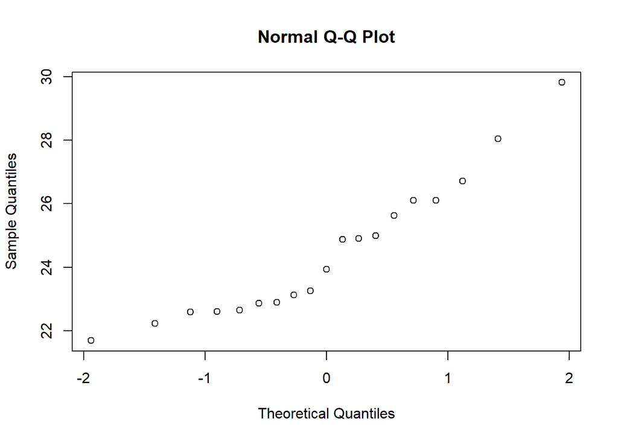

```r
qqnorm(chb$Ct)
```

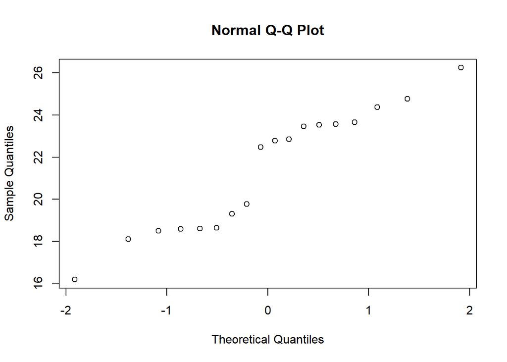

```r
qqnorm(csb$Ct)
```

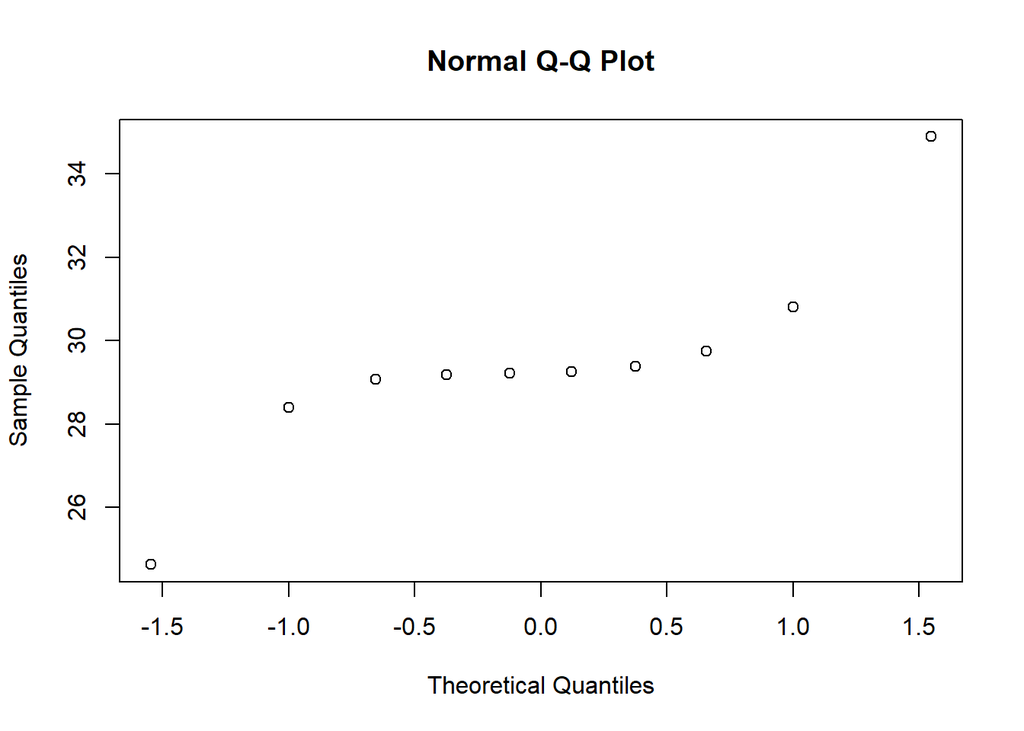

```r
qqnorm(mhb$Ct)
```

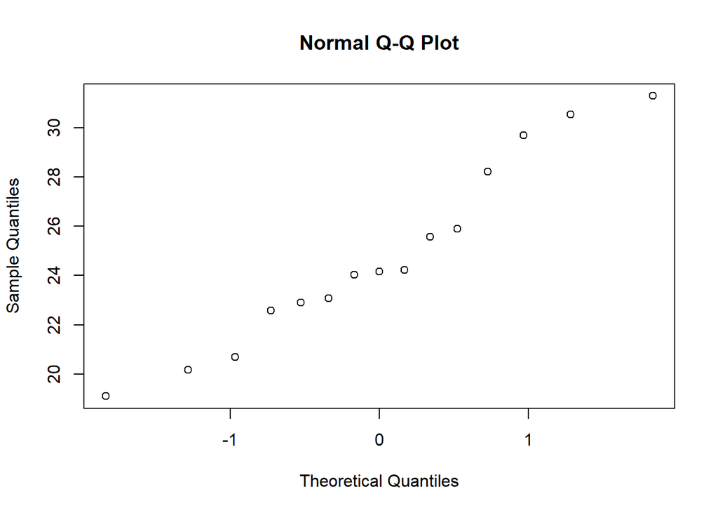

```r
qqnorm(msb$Ct)
```